# Sta112FS 15. Central Limit Theorem + CLT based inference, Pt. 1

November 3, 2015

## Today's agenda

## Today's agenda

- Central Limit Theorem
- Aside: Evaluating normality graphically
- Application exercise: proving the CLT via simulation
- Inference based on the Central Limit Theorem
- **Due Thursday:** Read Sections 2.5 - 2.8 on OpenIntro: Intro Stat with Randomization and Simulation: http://www.openintro.org/isrs

## Notation

## Notation

- Means:
  - Population: mean = \(\mu\), standard deviation = \(\sigma\)
  - Sample: mean = \(\bar{x}\), standard deviation = \(s\)
- Proportions:
  - Population: \(p\)
  - Sample: \(\hat{p}\)
- Standard error: \(SE\)

## Central Limit Theorem

## Variability of sample statistics

- Each sample from the population yields a slightly different sample statistic (sample mean, sample proportion, etc.)
- The variability of these sample statistics is measured by the **standard error**
- Previously we quantified this value via simulation
- Today we talk about the theory underlying **sampling distributions**

## Sampling distribution

- **Sampling distribution** is the distribution of sample statistics of random samples of size \(n\) taken from a population
- In practice it is impossible to construct sampling distributions since it would require having access to the entire population
- Today for demonstration purposes we will assume we have access to the population data, and construct sampling distributions, and examine their shapes, centers, and spreads

## Evaluating normality: Normal probability plots

## Normal probability plot

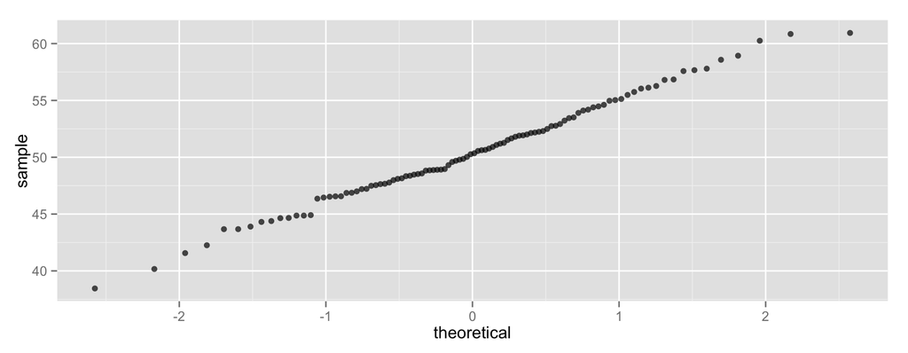

```r
d <- data.frame(norm_samp = rnorm(100, mean = 50, sd = 5))

ggplot(data = d, aes(sample = norm_samp)) +
  geom_point(alpha = 0.7, stat = "qq")
```

## Anatomy of a normal probability plot

- Data are plotted on the y-axis of a normal probability plot and theoretical quantiles (following a normal distribution) on the x-axis.
- If there is a one-to-one relationship between the data and the theoretical quantiles, then the data follow a nearly normal distribution.
- Since a one-to-one relationship would appear as a straight line on a scatter plot, the closer the points are to a perfect straight line, the more confident we can be that the data follow the normal model.

## Constructing a normal probability plot

[output not shown]

## Constructing a normal probability plot

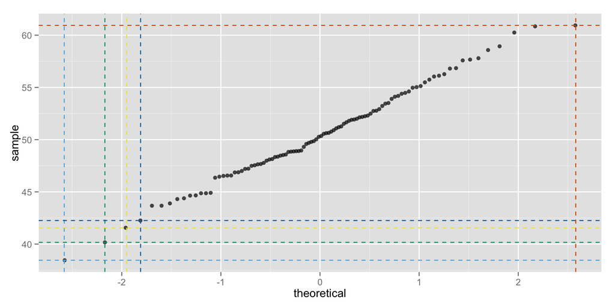

## Fat tails

Best to think about what is happening with the most extreme values - here the biggest values are bigger than we would expect and the smallest values are smaller than we would expect (for a normal).

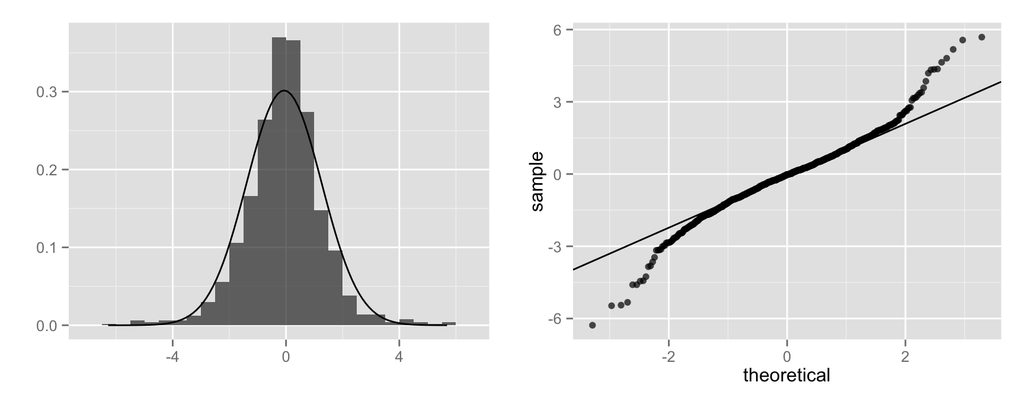

## Skinny tails

Here the biggest values are smaller than we would expect and the smallest values are bigger than we would expect.

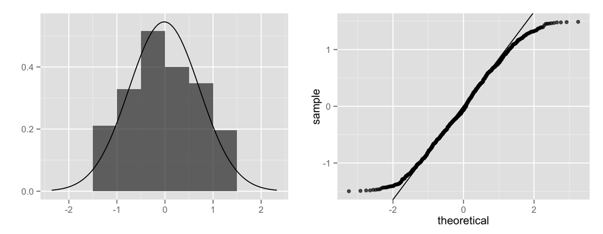

## Right skew

Here the biggest values are bigger than we would expect and the smallest values are also bigger than we would expect.

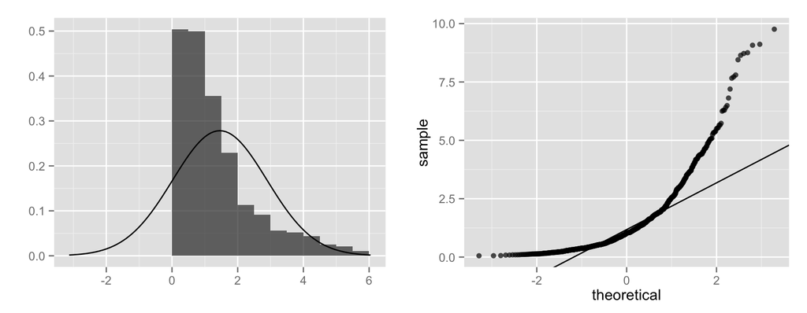

## Left skew

Here the biggest values are smaller than we would expect and the smallest values are also smaller than we would expect.

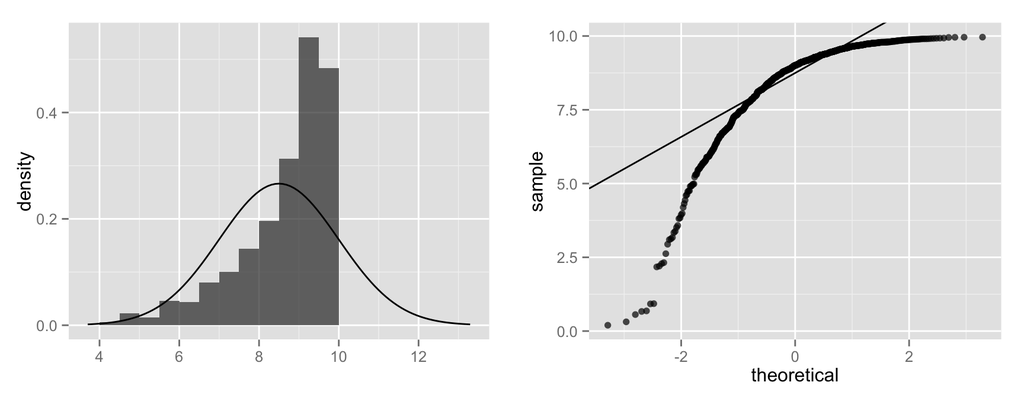

## Back to sampling distributions

## Application exercise

See course website for details